# ExtraaLearn Project

## Context

The EdTech industry has been surging in the past decade immensely, and according to a forecast, the Online Education market would be worth $286.62bn by 2023 with a compound annual growth rate (CAGR) of 10.26% from 2018 to 2023. The modern era of online education has enforced a lot in its growth and expansion beyond any limit. Due to having many dominant features like ease of information sharing, personalized learning experience, transparency of assessment, etc, it is now preferable to traditional education.

In the present scenario due to the Covid-19, the online education sector has witnessed rapid growth and is attracting a lot of new customers. Due to this rapid growth, many new companies have emerged in this industry. With the availability and ease of use of digital marketing resources, companies can reach out to a wider audience with their offerings. The customers who show interest in these offerings are termed as leads. There are various sources of obtaining leads for Edtech companies, like

- The customer interacts with the marketing front on social media or other online platforms.
- The customer browses the website/app and downloads the brochure
- The customer connects through emails for more information.

The company then nurtures these leads and tries to convert them to paid customers. For this, the representative from the organization connects with the lead on call or through email to share further details.

## Objective

ExtraaLearn is an initial stage startup that offers programs on cutting-edge technologies to students and professionals to help them upskill/reskill. With a large number of leads being generated on a regular basis, one of the issues faced by ExtraaLearn is to identify which of the leads are more likely to convert so that they can allocate resources accordingly. You, as a data scientist at ExtraaLearn, have been provided the leads data to:

- Analyze and build an ML model to help identify which leads are more likely to convert to paid customers,
- Find the factors driving the lead conversion process
- Create a profile of the leads which are likely to convert

## Data Description

The data contains the different attributes of leads and their interaction details with ExtraaLearn. The detailed data dictionary is given below.

**Data Dictionary**

- ID: ID of the lead
- age: Age of the lead
- current_occupation: Current occupation of the lead. Values include 'Professional','Unemployed',and 'Student'
- first_interaction: How did the lead first interacted with ExtraaLearn. Values include 'Website', 'Mobile App'
- profile_completed: What percentage of profile has been filled by the lead on the website/mobile app. Values include Low - (0-50%), Medium - (50-75%), High (75-100%)
- website_visits: How many times has a lead visited the website
- time_spent_on_website: Total time spent on the website
- page_views_per_visit: Average number of pages on the website viewed during the visits.
- last_activity: Last interaction between the lead and ExtraaLearn.
  - Email Activity: Seeking for details about program through email, Representative shared information with lead like brochure of program , etc
  - Phone Activity: Had a Phone Conversation with representative, Had conversation over SMS with representative, etc
  - Website Activity: Interacted on live chat with representative, Updated profile on website, etc
- print_media_type1: Flag indicating whether the lead had seen the ad of ExtraaLearn in the Newspaper.
- print_media_type2: Flag indicating whether the lead had seen the ad of ExtraaLearn in the Magazine.
- digital_media: Flag indicating whether the lead had seen the ad of ExtraaLearn on the digital platforms.
- educational_channels: Flag indicating whether the lead had heard about ExtraaLearn in the education channels like online forums, discussion threads, educational websites, etc.
- referral: Flag indicating whether the lead had heard about ExtraaLearn through reference.
- status: Flag indicating whether the lead was converted to a paid customer or not.

## Importing necessary libraries and data

```python
# Libraries to help with reading and manipulating data
import pandas as pd
import numpy as np

# Libaries to help with data visualization
import matplotlib.pyplot as plt
import seaborn as sns

# To tune model, get different metric scores, and split data
from sklearn import metrics
from sklearn.metrics import r2_score, mean_squared_error, mean_absolute_error
from sklearn.model_selection import train_test_split, StratifiedKFold, cross_val_score

# To impute missing values
from sklearn.impute import SimpleImputer

# To build classification models
from sklearn.tree import DecisionTreeClassifier
from sklearn.ensemble import BaggingClassifier
from sklearn.ensemble import RandomForestClassifier

# Metrics to evaluate the model
from sklearn import metrics
from sklearn.metrics import confusion_matrix, classification_report, precision_recall_curve, recall_score
from sklearn import tree

# For tuning the model
from sklearn.model_selection import GridSearchCV

# To define maximum number of columns to be displayed in a dataframe
pd.set_option("display.max_columns", None)

# To suppress scientific notations for a dataframe
pd.set_option("display.float_format", lambda x: "%.3f" % x)

# To suppress scientific notations
pd.set_option("display.float_format", lambda x: "%.3f" % x)

# To suppress warnings
import warnings
warnings.filterwarnings("ignore")

# This will help in making the Python code more structured automatically (good coding practice)
#%load_ext nb_black
```

```python
from google.colab import drive
drive.mount('/content/drive')
```

```python
# ExtraaLearn.csv
filepath = "/content/drive/MyDrive/MIT-IDSS/Week8/5-ProjectAssessment/"
df=pd.read_csv(filepath+'ExtraaLearn.csv')
```

## Data Overview

- Observations
- Sanity checks

The initial steps to get an overview of any dataset are to:

- observe the first few rows of the dataset to check whether the dataset has been loaded properly or not
- get information about the number of rows and columns in the dataset
- find out the data types of the columns to ensure that data is stored in the preferred format and the value of each property is as expected.
- check the statistical summary of the dataset to get an overview of the numerical columns of the data

### Displaying the first few rows of the dataset

```python
# let's view the first 5 rows of the data
df.head()
```

|  | ID | age | current_occupation | first_interaction | profile_completed | website_visits | time_spent_on_website | page_views_per_visit | last_activity | print_media_type1 | print_media_type2 | digital_media | educational_channels | referral | status |
| --- | --- | --- | --- | --- | --- | --- | --- | --- | --- | --- | --- | --- | --- | --- | --- |
| 0 | EXT001 | 57 | Unemployed | Website | High | 7 | 1639 | 1.861 | Website Activity | Yes | No | Yes | No | No | 1 |
| 1 | EXT002 | 56 | Professional | Mobile App | Medium | 2 | 83 | 0.320 | Website Activity | No | No | No | Yes | No | 0 |
| 2 | EXT003 | 52 | Professional | Website | Medium | 3 | 330 | 0.074 | Website Activity | No | No | Yes | No | No | 0 |
| 3 | EXT004 | 53 | Unemployed | Website | High | 4 | 464 | 2.057 | Website Activity | No | No | No | No | No | 1 |
| 4 | EXT005 | 23 | Student | Website | High | 4 | 600 | 16.914 | Email Activity | No | No | No | No | No | 0 |

```python
# let's view the last 5 rows of the data
df.tail()
```

|  | ID | age | current_occupation | first_interaction | profile_completed | website_visits | time_spent_on_website | page_views_per_visit | last_activity | print_media_type1 | print_media_type2 | digital_media | educational_channels | referral | status |
| --- | --- | --- | --- | --- | --- | --- | --- | --- | --- | --- | --- | --- | --- | --- | --- |
| 4607 | EXT4608 | 35 | Unemployed | Mobile App | Medium | 15 | 360 | 2.170 | Phone Activity | No | No | No | Yes | No | 0 |
| 4608 | EXT4609 | 55 | Professional | Mobile App | Medium | 8 | 2327 | 5.393 | Email Activity | No | No | No | No | No | 0 |
| 4609 | EXT4610 | 58 | Professional | Website | High | 2 | 212 | 2.692 | Email Activity | No | No | No | No | No | 1 |
| 4610 | EXT4611 | 57 | Professional | Mobile App | Medium | 1 | 154 | 3.879 | Website Activity | Yes | No | No | No | No | 0 |
| 4611 | EXT4612 | 55 | Professional | Website | Medium | 4 | 2290 | 2.075 | Phone Activity | No | No | No | No | No | 0 |

**Observations:**

The DataFrame has 15 columns as mentioned in the Data Dictionary. Data in each row or record corresponds to a lead.

Displayed both the first, and last 5 rows of leads by using head() and tail() functions to verify entries can be properly displayed.

**Notes :** The customers who show interest in the online education offerings are termed as leads

```python
# checking shape of the data
print("There are", df.shape[0], 'rows and', df.shape[1], "columns.")
```

```
There are 4612 rows and 15 columns.
```

### Checking for duplicate values

```python
# let's check for duplicate values in the data
df.duplicated().sum()
```

```
0
```

### Checking for missing values

```python
# let's check for missing values in the data
round(df.isnull().sum() / df.isnull().count() * 100, 2)
```

|  | 0 |
| --- | --- |
| ID | 0.000 |
| age | 0.000 |
| current_occupation | 0.000 |
| first_interaction | 0.000 |
| profile_completed | 0.000 |
| website_visits | 0.000 |
| time_spent_on_website | 0.000 |
| page_views_per_visit | 0.000 |
| last_activity | 0.000 |
| print_media_type1 | 0.000 |
| print_media_type2 | 0.000 |
| digital_media | 0.000 |
| educational_channels | 0.000 |
| referral | 0.000 |
| status | 0.000 |

**dtype:** float64

**Observations:**

- There are no duplicates and no missing values in the data.

### Checking the data types of the different columns in the dataset

```python
# let's check the data types of the columns in the dataset
df.info()
```

```
<class 'pandas.core.frame.DataFrame'>
RangeIndex: 4612 entries, 0 to 4611
Data columns (total 15 columns):
 #   Column                 Non-Null Count  Dtype
---  ------                 --------------  -----
 0   ID                     4612 non-null   object
 1   age                    4612 non-null   int64
 2   current_occupation     4612 non-null   object
 3   first_interaction      4612 non-null   object
 4   profile_completed      4612 non-null   object
 5   website_visits         4612 non-null   int64
 6   time_spent_on_website  4612 non-null   int64
 7   page_views_per_visit   4612 non-null   float64
 8   last_activity          4612 non-null   object
 9   print_media_type1      4612 non-null   object
 10  print_media_type2      4612 non-null   object
 11  digital_media          4612 non-null   object
 12  educational_channels   4612 non-null   object
 13  referral               4612 non-null   object
 14  status                 4612 non-null   int64
dtypes: float64(1), int64(4), object(10)
memory usage: 540.6+ KB
```

**Observations:**

- There are **4612 observations and 15 columns** in the dataset.
- All the columns have 4612 non-null values, i.e., **there are no missing values in the data.**
- There are 5 numerical columns in the data and 10 object type columns.
- ID, current_occupation, first_interaction, profile_completed, last_activity,print_media_type1, print_media_type2, digital_media, educational_channels, and referral are an 'object' data type (or categorical data type)
- Only page_views_per_visit is of type float64
- Rest of the numerical variables are type int64
- Memory usage is around 540 KB.

```python
df.nunique()
```

|  | 0 |
| --- | --- |
| ID | 4612 |
| age | 46 |
| current_occupation | 3 |
| first_interaction | 2 |
| profile_completed | 3 |
| website_visits | 27 |
| time_spent_on_website | 1623 |
| page_views_per_visit | 2414 |
| last_activity | 3 |
| print_media_type1 | 2 |
| print_media_type2 | 2 |
| digital_media | 2 |
| educational_channels | 2 |
| referral | 2 |
| status | 2 |

**dtype:** int64

**Observations:**

## **Data Preprocessing**

**Let's drop the ID column mentioned above** and define lists for numerical and categorical columns to explore them separately.

```python
# Dropping the columns
df=df.drop(['ID'],axis=1)
```

```python
# Creating numerical columns
num_cols=['age', 'website_visits', 'time_spent_on_website', 'page_views_per_visit', 'status'  ]

# Creating categorical variables
cat_cols= ['current_occupation', 'first_interaction', 'profile_completed',
            'last_activity', 'print_media_type1', 'print_media_type2', 'digital_media',
            'educational_channels', 'referral']
```

## Exploratory Data Analysis (EDA)

- EDA is an important part of any project involving data.
- It is important to investigate and understand the data better before building a model with it.
- A few questions have been mentioned below which will help you approach the analysis in the right manner and generate insights from the data.
- A thorough analysis of the data, in addition to the questions mentioned below, should be done.

### **Univariate analysis of numerical columns**

#### **Univariate analysis**

Let's explore these variables in some more depth by observing their distributions

#### **(1) Age of the lead:**

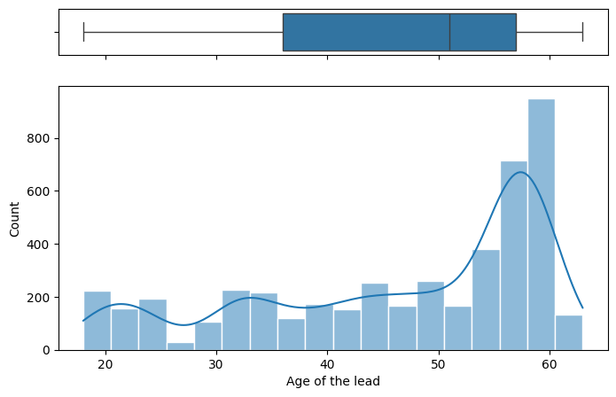

```python
f, (ax_box, ax_hist) = plt.subplots(2, sharex=True, gridspec_kw={'height_ratios': (.15, .85)}, figsize=(8, 5))
sns.set_style("darkgrid")

# Add a graph in each part
sns.boxplot(data=df, x="age", ax=ax_box)
sns.histplot(data=df, x="age", kde=True, ax=ax_hist)
ax_box.set(xlabel='Age of the lead')
ax_hist.set(xlabel='Age of the lead')

plt.show()
```

**Observations:**

- The distribution of Age is skewed to the left with most people around age of 57 to 63.
- The distribution between 18 and 57 is some what uniform.
- From the boxplot, median age is 51, and we do not see any outliers.

#### **(2) Website visits:**

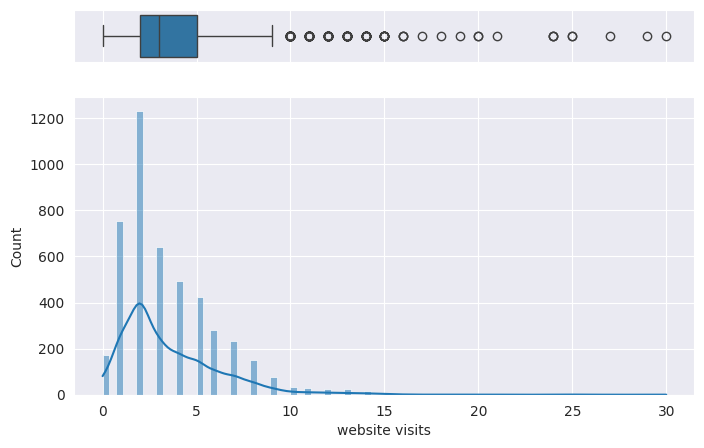

```python
f, (ax_box, ax_hist) = plt.subplots(2, sharex=True, gridspec_kw={'height_ratios': (.15, .85)}, figsize=(8, 5))
sns.set_style("darkgrid")

# Add a graph in each part
sns.boxplot(data=df, x="website_visits", ax=ax_box)
sns.histplot(data=df, x="website_visits", kde=True, ax=ax_hist)
ax_box.set(xlabel='website visits')
ax_hist.set(xlabel='website visits')

plt.show()
```

**Observations:**

- The distribution of the website_visits is skewed to the right, with a majority of leads visiting the website a few times.
- A long tail indicates some leads have visited the website significantly more often than others
- From the boxplot, media value is 3, and there are few outliers to right tail.

Let's handle outliers in the website_visits feature. Outliers can skew your analysis and affect model performance, especially in classification tasks.

There are 3 options available:

- Option 1: Remove outliers
- Option 2: Cap outliers
- Option 3: Replace outliers with median or mean

```python
# handle outliners in website_visits using Option 1

# Identify outliers using IQR
Q1 = df['website_visits'].quantile(0.25)
Q3 = df['website_visits'].quantile(0.75)
IQR = Q3 - Q1
lower_bound = Q1 - 1.5 * IQR
upper_bound = Q3 + 1.5 * IQR

# Option 1: Remove outliers
df_no_outliers = df[(df['website_visits'] >= lower_bound) & (df['website_visits'] <= upper_bound)]

f, (ax_box, ax_hist) = plt.subplots(2, sharex=True, gridspec_kw={'height_ratios': (.15, .85)}, figsize=(8, 5))
sns.set_style("darkgrid")

# Add a graph in each part
sns.boxplot(data=df, x="website_visits", ax=ax_box)
sns.histplot(data=df, x="website_visits", kde=True, ax=ax_hist)
ax_box.set(xlabel='Website visit')
ax_hist.set(xlabel='Website visit')
plt.show()
```

[output not shown]

```python
# handle outliners in website_visits using Option 2

# Identify outliers using IQR
Q1 = df['website_visits'].quantile(0.25)
Q3 = df['website_visits'].quantile(0.75)
IQR = Q3 - Q1
lower_bound = Q1 - 1.5 * IQR
upper_bound = Q3 + 1.5 * IQR

# Option 2: Cap outliers
df['website_visits'] = np.where(df['website_visits'] > upper_bound, upper_bound, df['website_visits'])
df['website_visits'] = np.where(df['website_visits'] < lower_bound, lower_bound, df['website_visits'])

f, (ax_box, ax_hist) = plt.subplots(2, sharex=True, gridspec_kw={'height_ratios': (.15, .85)}, figsize=(8, 5))
sns.set_style("darkgrid")

# Add a graph in each part
sns.boxplot(data=df, x="website_visits", ax=ax_box)
sns.histplot(data=df, x="website_visits", kde=True, ax=ax_hist)
ax_box.set(xlabel='Website visit')
ax_hist.set(xlabel='Website visit')
plt.show()
```

[output not shown]

```python
# handle outliners in website_visits using Option 3

# Identify outliers using IQR
Q1 = df['website_visits'].quantile(0.25)
Q3 = df['website_visits'].quantile(0.75)
IQR = Q3 - Q1
lower_bound = Q1 - 1.5 * IQR
upper_bound = Q3 + 1.5 * IQR

# Option 3: Replace outliers with median or mean
median_page_views = df['website_visits'].median()
df['website_visits'] = np.where(df['website_visits'] > upper_bound, median_page_views, df['website_visits'])
df['website_visits'] = np.where(df['website_visits'] < lower_bound, median_page_views, df['website_visits'])

f, (ax_box, ax_hist) = plt.subplots(2, sharex=True, gridspec_kw={'height_ratios': (.15, .85)}, figsize=(8, 5))
sns.set_style("darkgrid")

# Add a graph in each part
sns.boxplot(data=df, x="website_visits", ax=ax_box)
sns.histplot(data=df, x="website_visits", kde=True, ax=ax_hist)
ax_box.set(xlabel='Website visit')
ax_hist.set(xlabel='Website visit')
plt.show()
```

[output not shown]

**Observations:**

#### **(3) Time Spent on Website:**

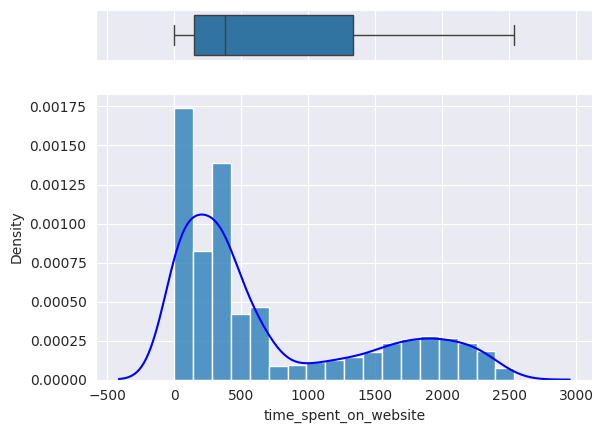

```python
f, (ax_box, ax_hist) = plt.subplots(2, sharex=True, gridspec_kw={"height_ratios": (.15, .85)})
sns.boxplot(data=df, x="time_spent_on_website", ax=ax_box)
sns.histplot(data=df, x="time_spent_on_website", ax=ax_hist, stat='density')
sns.kdeplot(data=df, x="time_spent_on_website", ax=ax_hist, color='blue')
ax_box.set(xlabel='time_spent_on_website')
plt.show()
```

**Observations:**

- The distribution of Time_spent_on_website is right-skewed indicating most of the leads spent a shorter amount of time on the website, while a small number of leads spent a longer time.
- From the boxplot, the median time spent on the website is around 380, and we can not see any outliers.

#### **(4) Page views per visit:**

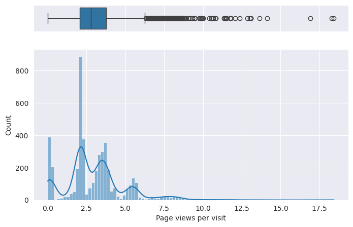

```python
f, (ax_box, ax_hist) = plt.subplots(2, sharex=True, gridspec_kw={'height_ratios': (.15, .85)}, figsize=(8, 5))
sns.set_style("darkgrid")

# Add a graph in each part
sns.boxplot(data=df, x="page_views_per_visit", ax=ax_box)
sns.histplot(data=df, x="page_views_per_visit", kde=True, ax=ax_hist)
ax_box.set(xlabel='Page views per visit')
ax_hist.set(xlabel='Page views per visit')
plt.show()
```

**Observations:**

- The distribution of page_views_per_visit is right-skewed, indicating that most leads view a smaller number of pages per visit.
- From the boxplot, the median number of page views per visit is around 2.8.
- There are quite a few outliers on the right tail, indicating a few leads who are visiting many pages per visit.

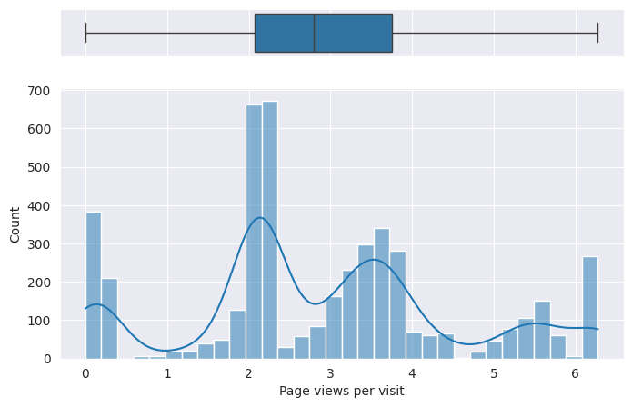

```python
# handle outliners in page_views_per_visit using Option 2

# Identify outliers using IQR
Q1 = df['page_views_per_visit'].quantile(0.25)
Q3 = df['page_views_per_visit'].quantile(0.75)
IQR = Q3 - Q1
lower_bound = Q1 - 1.5 * IQR
upper_bound = Q3 + 1.5 * IQR

# Option 2: Cap outliers
df['page_views_per_visit'] = np.where(df['page_views_per_visit'] > upper_bound, upper_bound, df['page_views_per_visit'])
df['page_views_per_visit'] = np.where(df['page_views_per_visit'] < lower_bound, lower_bound, df['page_views_per_visit'])

f, (ax_box, ax_hist) = plt.subplots(2, sharex=True, gridspec_kw={'height_ratios': (.15, .85)}, figsize=(8, 5))
sns.set_style("darkgrid")

# Add a graph in each part
sns.boxplot(data=df, x="page_views_per_visit", ax=ax_box)
sns.histplot(data=df, x="page_views_per_visit", kde=True, ax=ax_hist)
ax_box.set(xlabel='Page views per visit')
ax_hist.set(xlabel='Page views per visit')
plt.show()
```

**Observations:**

- The distribution of Page views per visit shows 4 peaks on 0, 2, 3.5 and 5.5. But most people are on the 2 page views per visit.
- The boxplot shows there is no more outliners after handling with Option 2.

#### **(5) Status:**

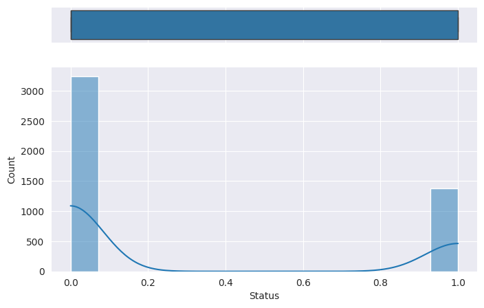

```python
f, (ax_box, ax_hist) = plt.subplots(2, sharex=True, gridspec_kw={'height_ratios': (.15, .85)}, figsize=(8, 5))
sns.set_style("darkgrid")

# Add a graph in each part
sns.boxplot(data=df, x="status", ax=ax_box)
sns.histplot(data=df, x="status", kde=True, ax=ax_hist)
ax_box.set(xlabel='Status')
ax_hist.set(xlabel='Status')
plt.show()
```

**Observations:**

- Majority of leads are not converted into paid customers (status=0) as shown on the histogram above.
- The distribution indicates a class imbalanced that needs to be addressed later on model building.
- From the boxplot, it shows there are 2 values. 0 for not converted and 1 for converted.

```python
# let's view the statistical summary of the numerical columns in the data
# df.describe().T
df[num_cols].describe().T
```

|  | count | mean | std | min | 25% | 50% | 75% | max |
| --- | --- | --- | --- | --- | --- | --- | --- | --- |
| age | 4612.000 | 46.201 | 13.161 | 18.000 | 36.000 | 51.000 | 57.000 | 63.000 |
| website_visits | 4612.000 | 3.450 | 2.393 | 0.000 | 2.000 | 3.000 | 5.000 | 9.500 |
| time_spent_on_website | 4612.000 | 724.011 | 743.829 | 0.000 | 148.750 | 376.000 | 1336.750 | 2537.000 |
| page_views_per_visit | 4612.000 | 2.915 | 1.658 | 0.000 | 2.078 | 2.792 | 3.756 | 6.274 |
| status | 4612.000 | 0.299 | 0.458 | 0.000 | 0.000 | 0.000 | 1.000 | 1.000 |

**Observations:**

Based on the output of describe(), we can gather some insights about the numerical columns

- **Average age of leads is around 46 years**. It has a high range, from 18 years to 63, indicating good age diversity interesting of online learning.
- The average number of website visits is around 3.5.
- The median time spent on the website is around 380.
- The median number of page views per visit is around 2.8
- The status has only 2 values, 0 and 1. and the average is 0.3, indicating that the majority of leads are not converted.

**Let's explore these variables in some more depth by observing their distributions**

### **Univariate analysis for categorical variables**

```python
df.describe(include=["object"]).T
```

|  | count | unique | top | freq |
| --- | --- | --- | --- | --- |
| current_occupation | 4612 | 3 | Professional | 2616 |
| first_interaction | 4612 | 2 | Website | 2542 |
| profile_completed | 4612 | 3 | High | 2264 |
| last_activity | 4612 | 3 | Email Activity | 2278 |
| print_media_type1 | 4612 | 2 | No | 4115 |
| print_media_type2 | 4612 | 2 | No | 4379 |
| digital_media | 4612 | 2 | No | 4085 |
| educational_channels | 4612 | 2 | No | 3907 |
| referral | 4612 | 2 | No | 4519 |

**Observations:**

It's valuable information for understanding the general tendencies of the leads, such as their employment status, interaction methods, and engagement with different marketing channels.

```python
# Printing the % sub categories of each category
for i in cat_cols:
    print(df[i].value_counts(normalize=True))
    print('*'*40)
```

```
current_occupation
Professional   0.567
Unemployed     0.312
Student        0.120
Name: proportion, dtype: float64
first_interaction
Website      0.551
Mobile App   0.449
Name: proportion, dtype: float64
profile_completed
High     0.491
Medium   0.486
Low      0.023
Name: proportion, dtype: float64
last_activity
Email Activity     0.494
Phone Activity     0.268
Website Activity   0.239
Name: proportion, dtype: float64
print_media_type1
No    0.892
Yes   0.108
Name: proportion, dtype: float64
print_media_type2
No    0.949
Yes   0.051
Name: proportion, dtype: float64
digital_media
No    0.886
Yes   0.114
Name: proportion, dtype: float64
educational_channels
No    0.847
Yes   0.153
Name: proportion, dtype: float64
referral
No    0.980
Yes   0.020
Name: proportion, dtype: float64
```

**Observations:**

- **About 57% are professional, 31% are unemployed, and 12% are students**, indicating the on-line learning are in higher demand by the professional as it is convenience and better fitted for their own schedules. People who are unemployed can also learn new skills easily to meet the current market needs.
- In terms of first interaction, both mobile app and website are being used almost equally with website slightly higher of 55%.
- Around 49% of both Medium (50-75%) and High (75-100%) profile have been filled by the lead on the website/mobile. Only 2% for Low (0-50%).
- **Around 49% last activity are from email.** This number appears to be on the higher side, and might indicate that people are interested, but want to get more written information before making a decision. Phone and website activity are split almost equally with 26% and 24% respectively.
- Lead had seen the ad of ExtraaLearn in the Newspaper, Magazine, Digital Media, and Educational channel are rather low with 10%, 5%, 11% and 15% respectively. The company could spend more effort and resource to increase this Ad out reaching.
- Only 2% are from referral indicating no incentative are provided to existing paid customers.

### **Bivariate and Multivariate analysis**

We have analyzed different categorical and numerical variables. Let's now check how does status = 1 of conversion to paid customer is related with other categorical variables.

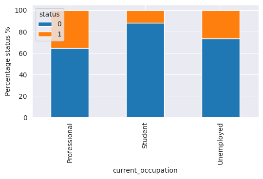

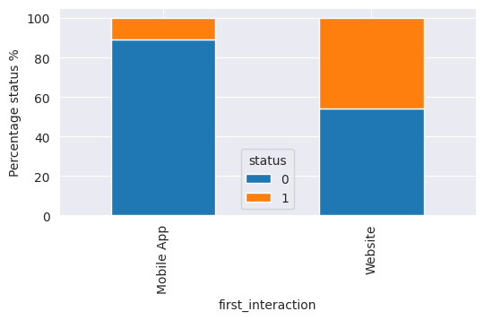

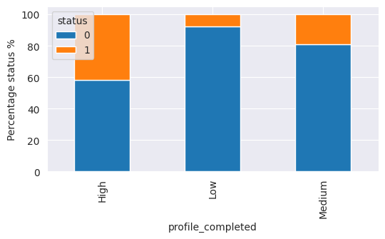

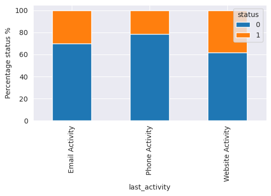

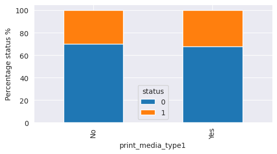

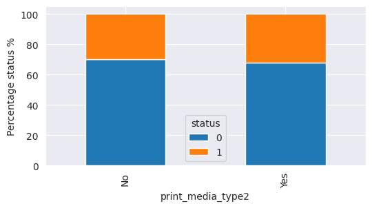

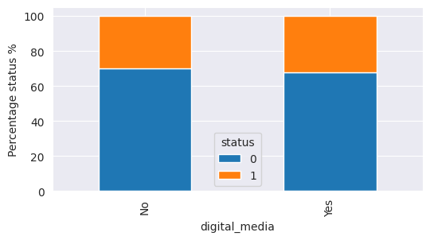

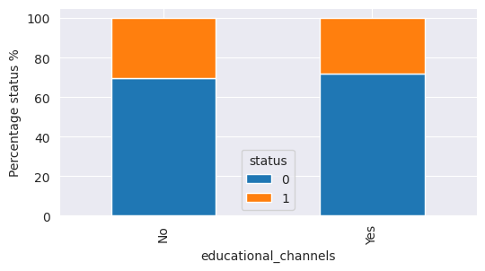

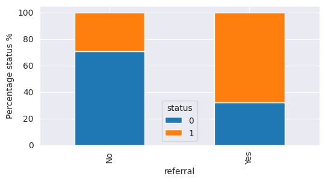

```python
for i in cat_cols:
    if i!='status':
        (pd.crosstab(df[i],df['status'],normalize='index')*100).plot(kind='bar',figsize=(6,3),stacked=True)
        plt.ylabel('Percentage status %')
```

**Observations:**

### 1. Current Occupation and Status:

- Professionals have a higher conversion rate to paid customers compared to unemployed or students.
- This indicates professionals are more likely to invest in online learning to enhance their skills to meet their job requirements.

### 2. First Interaction and Status:

- Leads who interacted through the website have a higher conversion rate compared to those who used mobile app.
- This suggests that the website is more effective in generating paid customer conversions.

### 3. Profile Completed and Status:

- Leads with medium and high profile completion show a significantly higher conversion rate compared to low profile completion.
- This indicates that the greater the effort of filling the profile on the website or mobile, the higher the chance to conversion to paid customer.

### 5. Print Media Type 1 & 2 and Status:

- There is no clear correlation of print media type 1 and 2 on the conversion status.

### 6. Digital Media and Status:

- There is no clear correlation of exposing to Digital media on the conversion status.

### 7. Educational Channels and Status:

- There is no clear correlation of exposing to Educational channels on the conversion status.
- The company could spend more effort and resource to increase this Ad for out reaching.

### 8. Referral and Status:

- Leads who came through referrals show a higher conversion rate, suggesting that referrals can be a great source of valuable leads.
- It also indicates that leads recommended from current customer or friend network have higher chances of being converted to paid customer.

### **Let's check the relationship (and correlation) between different numerical variables**

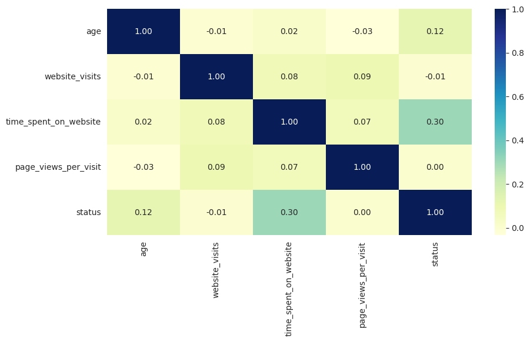

```python
# Plotting the correlation between numerical variables
plt.figure(figsize=(10,5))
sns.heatmap(df[num_cols].corr(),annot=True, fmt='0.2f', cmap='YlGnBu')
```

**Observations from Correlation Matrix:**

### 2. Website Visits and Page Views Per Visit:

- There is a weak positive correlation (0.09) between website visits and page views per visit.
- This indicates leads who visit the website more frequently also tend to view more pages per visit.

### 3. Age and Status:

- There is a positive correlation (0.12) between age and the status of conversion to paid customer.
- It suggests that older customers are more likely to become paid customers, potentially due to higher income or more established careers.

### 5. Time Spent on Website and Status:

- There is a positive correlation (0.30) between time spent on the website and the status of conversion to paid customer.
- This indicates that customers who spend more time on the website tend to have a higher conversion rate.

### Overall comments:

**Questions**

1. Leads will have different expectations from the outcome of the course and the current occupation may play a key role in getting them to participate in the program. Find out how current occupation affects lead status.
2. The company's first impression on the customer must have an impact. Do the first channels of interaction have an impact on the lead status?
3. The company uses multiple modes to interact with prospects. Which way of interaction works best?
4. The company gets leads from various channels such as print media, digital media, referrals, etc. Which of these channels have the highest lead conversion rate?
5. People browsing the website or mobile application are generally required to create a profile by sharing their personal data before they can access additional information.Does having more details about a prospect increase the chances of conversion?

# 1. Current Occupation vs Lead Status

Leads will have different expectations from the outcome of the course and the current occupation may play a key role in getting them to participate in the program. Find out how current occupation affects lead status.

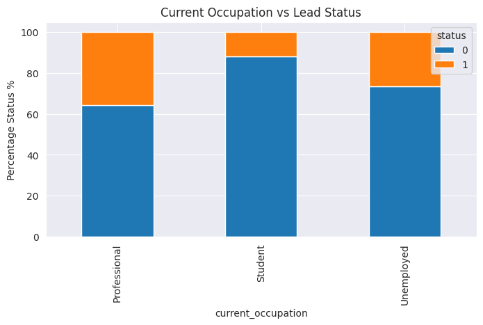

```python
(pd.crosstab(df['current_occupation'],df['status'],normalize='index')*100).plot(kind='bar',figsize=(8,4),stacked=True)
plt.ylabel('Percentage Status %')
plt.title('Current Occupation vs Lead Status')
```

**Observations:**

- Based on the visualization, professionals have a slightly higher conversion rate to paid customers compared to unemployed or students.
- About 57% are professional, 31% are unemployed, and 12% are students, indicating the on-line learning are in higher demand by the professional as it is convenience and better fitted for their own schedules.
- Unemployed individuals might also be looking to acquire new skills for better job prospects.
- Student has only 12% indicating they may have less financial resources or prioritize their current academic studies over online learning programs.

# 2. First channels of interaction vs Lead **Status**

The company's first impression on the customer must have an impact. Do the first channels of interaction have an impact on the lead status?

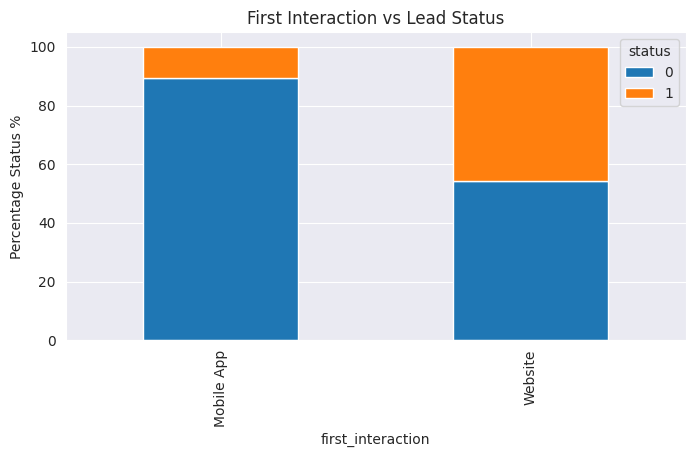

```python
(pd.crosstab(df['first_interaction'],df['status'],normalize='index')*100).plot(kind='bar',figsize=(8,4),stacked=True)
plt.ylabel('Percentage Status %')
plt.title('First Interaction vs Lead Status')
```

**Observations:**

- Based on the visualization, leads who interacted through the website have a higher conversion rate compared to the mobile app.
- It is possible that the user experience on the website is better, which could lead to a higher conversion rate.
- The mobile app could have usability issues that prevent users from converting.

# 3. Last Activity vs Lead Status

The company uses multiple modes to interact with prospects. Which way of interaction works best?

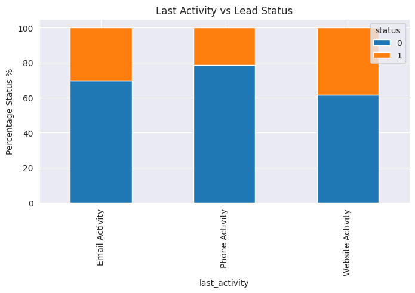

```python
(pd.crosstab(df['last_activity'],df['status'],normalize='index')*100).plot(kind='bar',figsize=(8,4),stacked=True)
plt.ylabel('Percentage Status %')
plt.title('Last Activity vs Lead Status')
```

**Observations:**

# 4. Channels have the highest lead conversion rate

The company gets leads from various channels such as print media, digital media, referrals, etc. Which of these channels have the highest lead conversion rate?

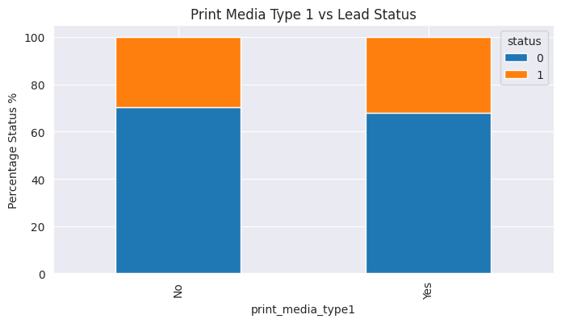

```python
(pd.crosstab(df['print_media_type1'],df['status'],normalize='index')*100).plot(kind='bar',figsize=(8,4),stacked=True)
plt.ylabel('Percentage Status %')
plt.title('Print Media Type 1 vs Lead Status')
```

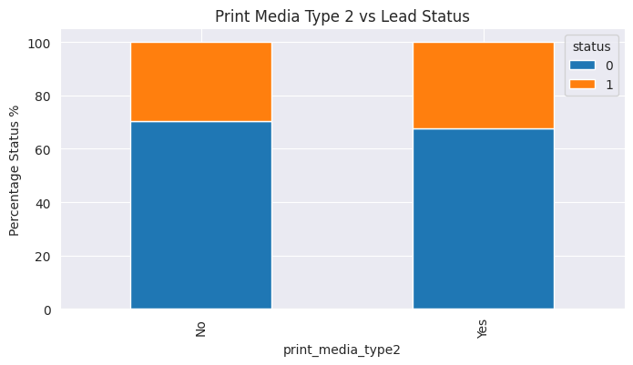

```python
(pd.crosstab(df['print_media_type2'],df['status'],normalize='index')*100).plot(kind='bar',figsize=(8,4),stacked=True)
plt.ylabel('Percentage Status %')
plt.title('Print Media Type 2 vs Lead Status')
```

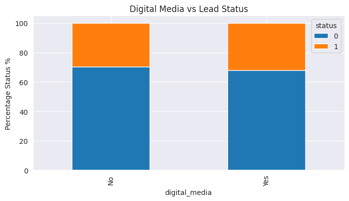

```python
(pd.crosstab(df['digital_media'],df['status'],normalize='index')*100).plot(kind='bar',figsize=(8,4),stacked=True)
plt.ylabel('Percentage Status %')
plt.title('Digital Media vs Lead Status')
```

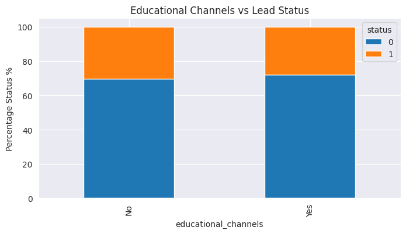

```python
(pd.crosstab(df['educational_channels'],df['status'],normalize='index')*100).plot(kind='bar',figsize=(8,4),stacked=True)
plt.ylabel('Percentage Status %')
plt.title('Educational Channels vs Lead Status')
```

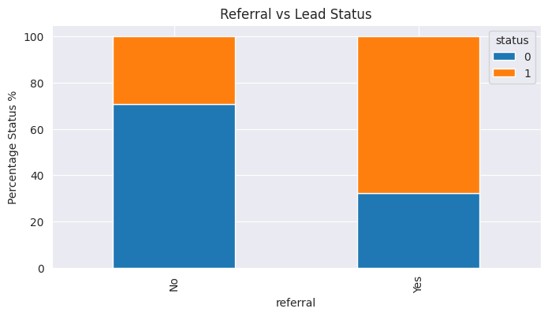

```python
(pd.crosstab(df['referral'],df['status'],normalize='index')*100).plot(kind='bar',figsize=(8,4),stacked=True)
plt.ylabel('Percentage Status %')
plt.title('Referral vs Lead Status')
```

**Observations:**

- Based on the visualizations, it appears that Referral has the highest lead conversion rate.
- This indicates that Referral is the most efficient channel for generating leads.
- The company should focus on improving its digital marketing strategies and optimizing its website to improve the chances of converting leads to paid customers.

# 5. Does having more details about a prospect increase the chances of conversion

People browsing the website or mobile application are generally required to create a profile by sharing their personal data before they can access additional information.Does having more details about a prospect increase the chances of conversion?

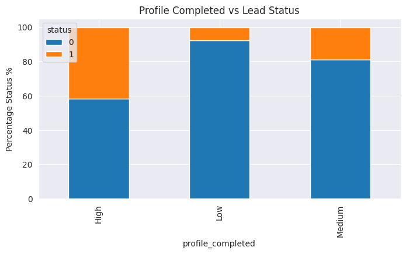

```python
(pd.crosstab(df['profile_completed'],df['status'],normalize='index')*100).plot(kind='bar',figsize=(8,4),stacked=True)
plt.ylabel('Percentage Status %')
plt.title('Profile Completed vs Lead Status')
```

**Observations:**

- Based on the visualization, it appears that leads who have completed their profiles have a higher chance of conversion to paid customers.
- This could be because customers who are more willing to provide their information might be more serious about taking the online course.
- When more details about a prospect are provided, it does increase the chances of conversion.
- The company should encourage leads to complete their profiles and provide incentives for doing so.

## Building decision tree model

**What is a Decision Tree?**

Decision Trees are a type of supervised machine learning algorithm that can be used for **both classification and regression tasks**. They are often used in business and industry for making decisions from a given dataset, and are particularly useful for tasks that require decision-making based on a set of conditions.

**How does a Decision Tree work?**

A Decision Tree works by recursively splitting the dataset into smaller subsets based on the feature that provides the most information gain at each step. This process continues until the subsets are as pure as possible, meaning that they contain as few mixed class labels as possible, or until a stopping criterion is met (e.g., when a maximum depth is reached).

$$\large Information\ Gain = Entropy\ before\ split - Entropy\ after\ split$$

where, $$\large Entropy = -\sum_{i=1}^{c} p_i \log_2 p_i$$

Here, $p$ is the proportion of positive instances in the subset.

The goal of the algorithm is to find the tree that provides the best predictions on the training data, while also being as simple and interpretable as possible.

### **Data preparation**

**Creating dummy variables for categorical Variables**

```python
# Creating dummy variables

df = pd.get_dummies(df, columns=cat_cols, drop_first=True)
```

```python
# Mapping status
status_mapping = {0: 'Not Converted', 1: 'Converted'}
df['status'] = df['status'].map(status_mapping)
```

**Separating the independent variables (X) and the dependent variable (Y)**

```python
# Separating target variable and other variables

Y= df.status
X= df.drop(columns = ['status'])
```

```python
# Splitting the data
X_train, X_test, y_train, y_test = train_test_split(X, Y, test_size = 0.3, random_state = 1, stratify = Y)

# Checking the shape of the data
print(X_train.shape, X_test.shape, y_train.shape, y_test.shape)
```

```
(3228, 16) (1384, 16) (3228,) (1384,)
```

```python
from sklearn.tree import DecisionTreeClassifier

# Building decision tree model
# Change the class_weight to reflect the actual class labels
dt = DecisionTreeClassifier(class_weight = {'Not Converted': 0.17, 'Converted': 0.83}, random_state = 1)

# Fitting decision tree model
dt.fit(X_train, y_train)
```

```
DecisionTreeClassifier(class_weight={'Converted': 0.83, 'Not Converted': 0.17},
                       random_state=1)
```

```python
# Creating metric function
def metrics_score(actual, predicted):
    print(classification_report(actual, predicted))

    cm = confusion_matrix(actual, predicted)
    plt.figure(figsize=(8,5))

    sns.heatmap(cm, annot=True,  fmt='.2f', xticklabels=['Not Converted', 'Converted'], yticklabels=['Not Converted', 'Converted'])
    plt.ylabel('Actual')
    plt.xlabel('Predicted')
    plt.show()
```

**Let's check the model performance of decision tree**

```
               precision    recall  f1-score   support

    Converted       1.00      1.00      1.00       964
Not Converted       1.00      1.00      1.00      2264

     accuracy                           1.00      3228
    macro avg       1.00      1.00      1.00      3228
 weighted avg       1.00      1.00      1.00      3228
```

[figure not shown]

```python
# Checking performance on the training dataset
y_train_pred_dt = dt.predict(X_train)

metrics_score(y_train, y_train_pred_dt)
```

**Observation:**

- The Decision tree is giving a strong performance of **100% score for all metrics on the training dataset**, indicating it is overfitting.
- This suggests the model is too complex and has learned the noise and specific patterns of the training data, which may not generalize well to new unseen data.
- The reported average includes the macro average which averages the unweighted mean per label, and the weighted average i.e. averaging the support-weighted mean per label.
- In classification, the class of interest is considered the positive class. Here, the class of interest is "Converted" with (value=1) i.e. identifying the customers who are converted to paid customers. "Not Converted" corresponds with (value=0).

**Reading the confusion matrix (clockwise):**

- True Negative (Actual=0, Predicted=0): Model predicts that a customer would not convert and the customer does not convert
- False Positive (Actual=0, Predicted=1): Model predicts that a customer would convert but the customer does not convert
- False Negative (Actual=1, Predicted=0): Model predicts that a customer would not convert but the customer converts
- True Positive (Actual=1, Predicted=1): Model predicts that a customer would convert and the customer converts

```
               precision    recall  f1-score   support

    Converted       0.68      0.66      0.67       413
Not Converted       0.86      0.87      0.86       971

     accuracy                           0.80      1384
    macro avg       0.77      0.76      0.76      1384
 weighted avg       0.80      0.80      0.80      1384
```

[figure not shown]

```python
# Checking performance on the test dataset
y_test_pred_dt = dt.predict(X_test)

metrics_score(y_test, y_test_pred_dt)
```

**Observations:**

- The Decision Tree works well on the training data but **not so well on the test data** as the recall is 0.66 in comparison to 1 for the training dataset, i.e., the Decision Tree is overfitting the training data.
- The precision on the test data suggests that there's a 32% (1 - 0.68) chance that the model will predict that a lead is going to be converted even though he/she would not, and **the company may waste their time and energy on these leads who will not be converted to paid customers.**
- The results suggest that the model is too complex and has learned the noise and specific patterns of the training data, which may not generalize well to new leads.

```python
# what is the Accuracy
from sklearn.metrics import accuracy_score

accuracy = accuracy_score(y_test, y_test_pred_dt)
print("Accuracy before Tunning:", accuracy)
```

```
Accuracy before Tunning: 0.8041907514450867
```

**Let's plot the feature importance and check the most important features.**

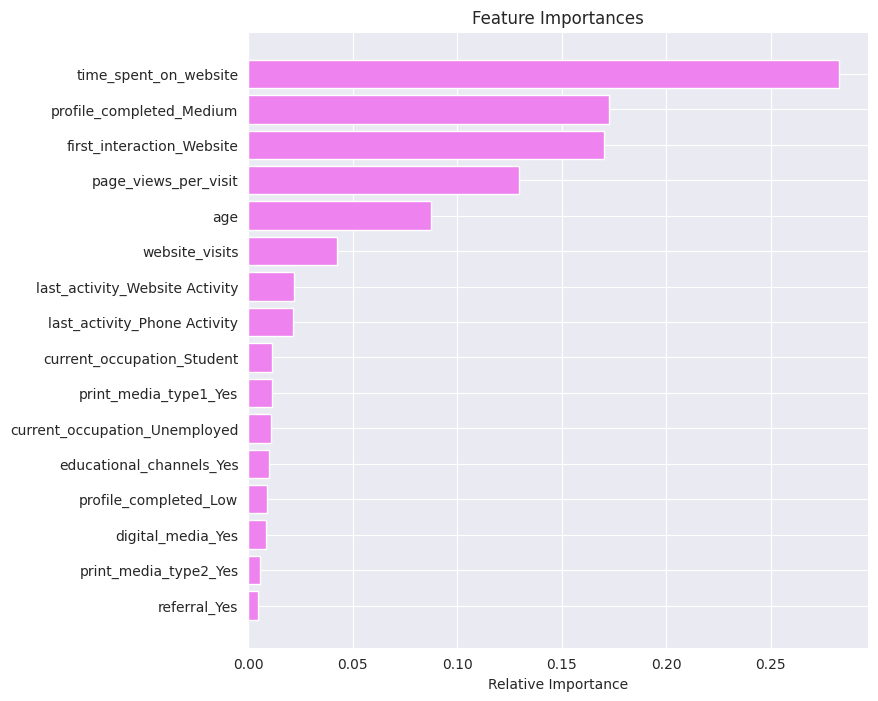

```python
# Importance of features in the tree building

feature_names = list(X_train.columns)
importances = dt.feature_importances_
indices = np.argsort(importances)

plt.figure(figsize=(8, 8))
plt.title("Feature Importances")
plt.barh(range(len(indices)), importances[indices], color="violet", align="center")
plt.yticks(range(len(indices)), [feature_names[i] for i in indices])
plt.xlabel("Relative Importance")
plt.show()
```

# Print top 10 important features

```python
# Check Feature Importance and comment on important features
importance_df = pd.DataFrame({'Feature': X_train.columns, 'Importance': dt.feature_importances_})
importance_df = importance_df.sort_values('Importance', ascending=False)
print(importance_df.head(10))  # Print top 10 important features
```

```
                           Feature  Importance
2            time_spent_on_website       0.283
8         profile_completed_Medium       0.173
6        first_interaction_Website       0.170
3             page_views_per_visit       0.130
0                              age       0.088
1                   website_visits       0.043
10  last_activity_Website Activity       0.022
9     last_activity_Phone Activity       0.021
4       current_occupation_Student       0.012
11           print_media_type1_Yes       0.011
```

**Observations:**

**Let's visualize the decision tree** and observe the decision rules:

As we know the decision tree keeps growing until the nodes are homogeneous, i.e., it has only one class, and the dataset here has a lot of features, it would be hard to visualize the whole tree with so many features. Therefore, we are only visualizing the tree up to **max_depth = 4**.

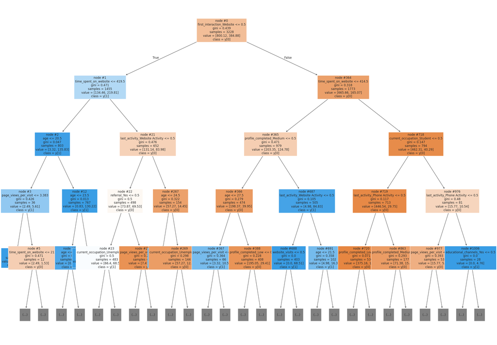

```python
features = list(X.columns)

plt.figure(figsize = (35, 25))
tree.plot_tree(dt, max_depth = 4, feature_names = features, filled = True, fontsize = 12, node_ids = True, class_names = True)
plt.show()
```

### **Observations:**

To interpret a decision tree, you can follow a path from the root node to a leaf node. Along the path, you can see the tests performed on the features, and based on the test results, the data is split into smaller subsets.

**Note:** The tree is truncated and not shown completely to get proper visualization. You can try to plot the complete tree and get some more observations.

# Do we need to prune the tree

- Yes, we need to prune the tree.
- The Decision Tree model is overfitting the training data, as indicated by its perfect performance on the training set and relatively lower performance on the test set.
- This suggests that the tree is too complex and has learned the training data's noise and specific details.
- Pruning techniques, such as setting a maximum depth, minimum samples per leaf, or using cost complexity pruning, can help reduce overfitting.
- By limiting the tree's growth, we can prevent it from memorizing the training data and improve its generalization ability on unseen data.
- We can try different pruning techniques and evaluate the model's performance on the test set to find the best balance between complexity and accuracy.

### **Tuning Models**

- **Hyperparameters** are the parameters that govern the entire training process.
- **Hyperparameter tuning** is the process of finding optimal hyperparameters for a model that can lead to improvements in the overall model’s performance and can also help in reducing both overfitting and underfitting.

Tune the model hyperparameters using GridSearchCV

```
Best parameters: {'criterion': 'gini', 'max_depth': 15, 'min_samples_leaf': 1, 'min_samples_split': 2}
Best score: 0.8209455924352607
               precision    recall  f1-score   support

    Converted       0.66      0.71      0.69       413
Not Converted       0.87      0.84      0.86       971

     accuracy                           0.80      1384
    macro avg       0.77      0.78      0.77      1384
 weighted avg       0.81      0.80      0.81      1384
```

[figure not shown]

```python
# Define the parameter grid for GridSearchCV
param_grid = {
    'criterion': ['gini', 'entropy'],
    'max_depth': [None, 5, 10, 15],
    'min_samples_split': [2, 5, 10],
    'min_samples_leaf': [1, 2, 4]
}

# Create a DecisionTreeClassifier object
dt_grid = DecisionTreeClassifier(class_weight = {'Not Converted': 0.17, 'Converted': 0.83}, random_state = 1)

# Create a GridSearchCV object
grid_search = GridSearchCV(estimator=dt_grid, param_grid=param_grid, cv=5, scoring='accuracy')

# Fit the GridSearchCV object to the training data
grid_search.fit(X_train, y_train)

# Print the best parameters and the best score
print("Best parameters:", grid_search.best_params_)
print("Best score:", grid_search.best_score_)

# Create a DecisionTreeClassifier with the best parameters
best_dt = DecisionTreeClassifier(**grid_search.best_params_, class_weight = {'Not Converted': 0.17, 'Converted': 0.83}, random_state = 1)

# Fit the best model to the training data
best_dt.fit(X_train, y_train)

# Make predictions on the test data
y_test_pred_best_dt = best_dt.predict(X_test)

# Evaluate the best model
metrics_score(y_test, y_test_pred_best_dt)
```

```python
# what is the Accuracy after GridSearchCV
from sklearn.metrics import accuracy_score

accuracy = accuracy_score(y_test, y_test_pred_best_dt)
print("Accuracy after GridSearchCV:", accuracy)
```

```
Accuracy after GridSearchCV: 0.8049132947976878
```

**Observations:**

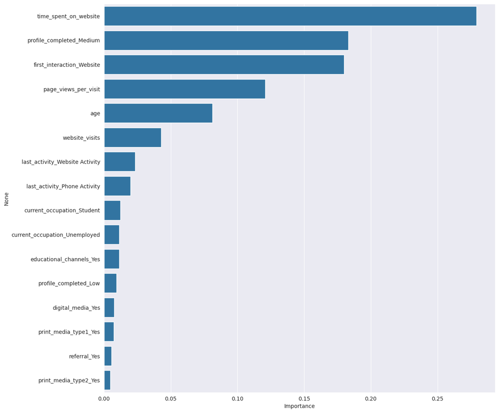

```python
importances = best_dt.feature_importances_  # Use best_dt instead of dt_grid
columns = X.columns

importance_df = pd.DataFrame(importances, index=columns, columns=['Importance']).sort_values(by='Importance', ascending=False)

plt.figure(figsize=(13, 13))
sns.barplot(data=importance_df, x='Importance', y=importance_df.index)
plt.show()
```

**Observations:**

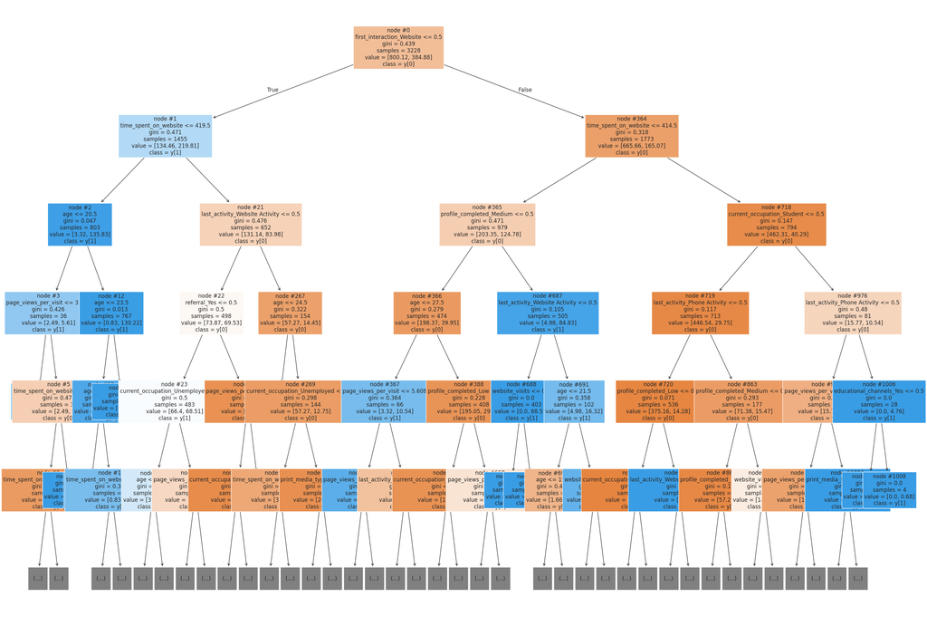

```python
features = list(X.columns)

plt.figure(figsize = (35, 25))

tree.plot_tree(dt, max_depth = 5, feature_names = features, filled = True, fontsize = 12, node_ids = True, class_names = True)

plt.show()
```